# Final Project Phase 2 - Home Credit Default Risk

Spring 2024

**Team Members:**

- Glen Colletti
- Alex Bordanca
- Paul Miller

## Abstract

> "The project is based on the [Home Credit Default Risk (HCDR) Kaggle Competition](https://www.kaggle.com/competitions/home-credit-default-risk/overview). The goal of the competition is to predict whether or not a client will repay a loan. In order to make sure that people who struggle to get loans due to insufficient or non-existent credit histories have a positive loan experience, Home Credit makes use of a variety of alternative data--including telco and transactional information--to predict their clients' repayment abilities."

During this phase of the project the team will accomplish the following tasks:

- Download and load the data from Kaggle.
- Perform exploratory data analysis (EDA).
- Define several baseline classification models using KNN, XG Boost and Logistic Regression.
- Create pipelines to standardize any numerical feature and one hot encode categorial features.
- Calculate several metrics to evaluate each model and pipeline.
- Record 2 minute video discussing our progress.

```python
from pandas import concat, DataFrame,read_csv, set_option
import matplotlib.pyplot as plt
%matplotlib inline

from __future__ import print_function

import numpy as np

from sklearn.compose import ColumnTransformer
from sklearn.impute import SimpleImputer
from sklearn.linear_model import LogisticRegression
from sklearn.model_selection import train_test_split, GridSearchCV
from sklearn.metrics import accuracy_score, f1_score
from sklearn.neighbors import KNeighborsClassifier
from sklearn.pipeline import Pipeline
from sklearn.preprocessing import StandardScaler, OneHotEncoder

from xgboost import XGBClassifier

np.random.seed(0)
```

All data downloaded from Kaggle:

https://www.kaggle.com/competitions/home-credit-default-risk/data

There are several other data files which contain information regarding a customer's financial profile, payment history etc obtained from Kaggle:

- `bureau.csv`
- `bureau_balance.csv`
- `credit_card_balance.csv`
- `installments_payments.csv`
- `previous_application.csv`
- `POS_CASH_balance.csv`

The baseline pipelines will only use data loaded from `application_train.csv`

```python
train_data = read_csv('data/application_train.csv')

print(f'Loaded {train_data.shape[0]:,} records.')
print()
train_data.head()
```

```
Loaded 307,511 records.
```

|  | SK_ID_CURR | TARGET | NAME_CONTRACT_TYPE | CODE_GENDER | FLAG_OWN_CAR | FLAG_OWN_REALTY | CNT_CHILDREN | AMT_INCOME_TOTAL | AMT_CREDIT | AMT_ANNUITY | ... | FLAG_DOCUMENT_18 | FLAG_DOCUMENT_19 | FLAG_DOCUMENT_20 | FLAG_DOCUMENT_21 | AMT_REQ_CREDIT_BUREAU_HOUR | AMT_REQ_CREDIT_BUREAU_DAY | AMT_REQ_CREDIT_BUREAU_WEEK | AMT_REQ_CREDIT_BUREAU_MON | AMT_REQ_CREDIT_BUREAU_QRT | AMT_REQ_CREDIT_BUREAU_YEAR |
| --- | --- | --- | --- | --- | --- | --- | --- | --- | --- | --- | --- | --- | --- | --- | --- | --- | --- | --- | --- | --- | --- |
| 0 | 100002 | 1 | Cash loans | M | N | Y | 0 | 202500.0 | 406597.5 | 24700.5 | ... | 0 | 0 | 0 | 0 | 0.0 | 0.0 | 0.0 | 0.0 | 0.0 | 1.0 |
| 1 | 100003 | 0 | Cash loans | F | N | N | 0 | 270000.0 | 1293502.5 | 35698.5 | ... | 0 | 0 | 0 | 0 | 0.0 | 0.0 | 0.0 | 0.0 | 0.0 | 0.0 |
| 2 | 100004 | 0 | Revolving loans | M | Y | Y | 0 | 67500.0 | 135000.0 | 6750.0 | ... | 0 | 0 | 0 | 0 | 0.0 | 0.0 | 0.0 | 0.0 | 0.0 | 0.0 |
| 3 | 100006 | 0 | Cash loans | F | N | Y | 0 | 135000.0 | 312682.5 | 29686.5 | ... | 0 | 0 | 0 | 0 | NaN | NaN | NaN | NaN | NaN | NaN |
| 4 | 100007 | 0 | Cash loans | M | N | Y | 0 | 121500.0 | 513000.0 | 21865.5 | ... | 0 | 0 | 0 | 0 | 0.0 | 0.0 | 0.0 | 0.0 | 0.0 | 0.0 |

5 rows × 122 columns

## Data Dictionary

As provided in the Kaggle data.

```python
data_dictionary = read_csv('data/HomeCredit_columns_description.csv')
data_dictionary.head(3)
```

|  | Unnamed: 0 | Table | Row | Description | Special |
| --- | --- | --- | --- | --- | --- |
| 0 | 1 | application_{train\|test}.csv | SK_ID_CURR | ID of loan in our sample | NaN |
| 1 | 2 | application_{train\|test}.csv | TARGET | Target variable (1 - client with payment difficulties: he/she had late payment more than X days on at least one of the first Y installments of the loan in our sample, 0 - all other cases) | NaN |
| 2 | 5 | application_{train\|test}.csv | NAME_CONTRACT_TYPE | Identification if loan is cash or revolving | NaN |

Display all columns and their descriptions in the application_train and test data.

```python
# Drop first column (an unneeded index)
data_dictionary.drop('Unnamed: 0', axis=1, inplace=True)


set_option('display.max_columns', None)
set_option('display.max_rows', None)
set_option('display.max_colwidth', None)
data_dictionary[data_dictionary['Table'] == 'application_{train|test}.csv']
```

|  | Table | Row | Description | Special |
| --- | --- | --- | --- | --- |
| 0 | application_{train\|test}.csv | SK_ID_CURR | ID of loan in our sample | NaN |
| 1 | application_{train\|test}.csv | TARGET | Target variable (1 - client with payment difficulties: he/she had late payment more than X days on at least one of the first Y installments of the loan in our sample, 0 - all other cases) | NaN |
| 2 | application_{train\|test}.csv | NAME_CONTRACT_TYPE | Identification if loan is cash or revolving | NaN |
| 3 | application_{train\|test}.csv | CODE_GENDER | Gender of the client | NaN |
| 4 | application_{train\|test}.csv | FLAG_OWN_CAR | Flag if the client owns a car | NaN |
| 5 | application_{train\|test}.csv | FLAG_OWN_REALTY | Flag if client owns a house or flat | NaN |
| 6 | application_{train\|test}.csv | CNT_CHILDREN | Number of children the client has | NaN |
| 7 | application_{train\|test}.csv | AMT_INCOME_TOTAL | Income of the client | NaN |
| 8 | application_{train\|test}.csv | AMT_CREDIT | Credit amount of the loan | NaN |
| 9 | application_{train\|test}.csv | AMT_ANNUITY | Loan annuity | NaN |
| 10 | application_{train\|test}.csv | AMT_GOODS_PRICE | For consumer loans it is the price of the goods for which the loan is given | NaN |
| 11 | application_{train\|test}.csv | NAME_TYPE_SUITE | Who was accompanying client when he was applying for the loan | NaN |
| 12 | application_{train\|test}.csv | NAME_INCOME_TYPE | Clients income type (businessman, working, maternity leave,…) | NaN |
| 13 | application_{train\|test}.csv | NAME_EDUCATION_TYPE | Level of highest education the client achieved | NaN |
| 14 | application_{train\|test}.csv | NAME_FAMILY_STATUS | Family status of the client | NaN |
| 15 | application_{train\|test}.csv | NAME_HOUSING_TYPE | What is the housing situation of the client (renting, living with parents, ...) | NaN |
| 16 | application_{train\|test}.csv | REGION_POPULATION_RELATIVE | Normalized population of region where client lives (higher number means the client lives in more populated region) | normalized |
| 17 | application_{train\|test}.csv | DAYS_BIRTH | Client's age in days at the time of application | time only relative to the application |
| 18 | application_{train\|test}.csv | DAYS_EMPLOYED | How many days before the application the person started current employment | time only relative to the application |
| 19 | application_{train\|test}.csv | DAYS_REGISTRATION | How many days before the application did client change his registration | time only relative to the application |
| 20 | application_{train\|test}.csv | DAYS_ID_PUBLISH | How many days before the application did client change the identity document with which he applied for the loan | time only relative to the application |
| 21 | application_{train\|test}.csv | OWN_CAR_AGE | Age of client's car | NaN |
| 22 | application_{train\|test}.csv | FLAG_MOBIL | Did client provide mobile phone (1=YES, 0=NO) | NaN |
| 23 | application_{train\|test}.csv | FLAG_EMP_PHONE | Did client provide work phone (1=YES, 0=NO) | NaN |
| 24 | application_{train\|test}.csv | FLAG_WORK_PHONE | Did client provide home phone (1=YES, 0=NO) | NaN |
| 25 | application_{train\|test}.csv | FLAG_CONT_MOBILE | Was mobile phone reachable (1=YES, 0=NO) | NaN |
| 26 | application_{train\|test}.csv | FLAG_PHONE | Did client provide home phone (1=YES, 0=NO) | NaN |
| 27 | application_{train\|test}.csv | FLAG_EMAIL | Did client provide email (1=YES, 0=NO) | NaN |
| 28 | application_{train\|test}.csv | OCCUPATION_TYPE | What kind of occupation does the client have | NaN |
| 29 | application_{train\|test}.csv | CNT_FAM_MEMBERS | How many family members does client have | NaN |

[output cut: 92 more lines]

## Exploratory Data Analysis (EDA)

```python
train_data.info(verbose=True)
```

```
<class 'pandas.core.frame.DataFrame'>
RangeIndex: 307511 entries, 0 to 307510
Data columns (total 122 columns):
 #    Column                        Dtype
---   ------                        -----
 0    SK_ID_CURR                    int64
 1    TARGET                        int64
 2    NAME_CONTRACT_TYPE            object
 3    CODE_GENDER                   object
 4    FLAG_OWN_CAR                  object
 5    FLAG_OWN_REALTY               object
 6    CNT_CHILDREN                  int64
 7    AMT_INCOME_TOTAL              float64
 8    AMT_CREDIT                    float64
 9    AMT_ANNUITY                   float64
```

[output cut: 114 more lines]

```python
# NUMERICAL FEATURES
train_data.describe()
```

```python
# ALL FEATURES
train_data.describe(include='all')
```

Explore missing data in training dataset

```python
#MISSING DATA FOR APPLICATION TRAIN

percent = (train_data.isnull().sum() / train_data.isnull().count()*100).sort_values(ascending = False).round(2)
sum_missing = train_data.isna().sum().sort_values(ascending = False)
missing_application_train_data  = concat([percent, sum_missing], axis=1, keys=['Percent', "Train Missing Count"])
missing_application_train_data.head(20)
```

|  | Percent | Train Missing Count |
| --- | --- | --- |
| COMMONAREA_MEDI | 69.87 | 214865 |
| COMMONAREA_AVG | 69.87 | 214865 |
| COMMONAREA_MODE | 69.87 | 214865 |
| NONLIVINGAPARTMENTS_MODE | 69.43 | 213514 |
| NONLIVINGAPARTMENTS_AVG | 69.43 | 213514 |
| NONLIVINGAPARTMENTS_MEDI | 69.43 | 213514 |
| FONDKAPREMONT_MODE | 68.39 | 210295 |
| LIVINGAPARTMENTS_MODE | 68.35 | 210199 |
| LIVINGAPARTMENTS_AVG | 68.35 | 210199 |
| LIVINGAPARTMENTS_MEDI | 68.35 | 210199 |
| FLOORSMIN_AVG | 67.85 | 208642 |
| FLOORSMIN_MODE | 67.85 | 208642 |
| FLOORSMIN_MEDI | 67.85 | 208642 |
| YEARS_BUILD_MEDI | 66.50 | 204488 |
| YEARS_BUILD_MODE | 66.50 | 204488 |
| YEARS_BUILD_AVG | 66.50 | 204488 |
| OWN_CAR_AGE | 65.99 | 202929 |
| LANDAREA_MEDI | 59.38 | 182590 |
| LANDAREA_MODE | 59.38 | 182590 |
| LANDAREA_AVG | 59.38 | 182590 |

## Correlations

Find the features most correlated to the target. List the 10 most positive and 10 most negative

```python
correlations = train_data.corr()['TARGET'].sort_values()
print('Most Positive Correlations:\n', correlations.tail(10))
print('\nMost Negative Correlations:\n', correlations.head(10))
```

```
Most Positive Correlations:
 FLAG_DOCUMENT_3                0.044346
REG_CITY_NOT_LIVE_CITY         0.044395
FLAG_EMP_PHONE                 0.045982
REG_CITY_NOT_WORK_CITY         0.050994
DAYS_ID_PUBLISH                0.051457
DAYS_LAST_PHONE_CHANGE         0.055218
REGION_RATING_CLIENT           0.058899
REGION_RATING_CLIENT_W_CITY    0.060893
DAYS_BIRTH                     0.078239
TARGET                         1.000000
Name: TARGET, dtype: float64

Most Negative Correlations:
 EXT_SOURCE_3                 -0.178919
EXT_SOURCE_2                 -0.160472
EXT_SOURCE_1                 -0.155317
DAYS_EMPLOYED                -0.044932
FLOORSMAX_AVG                -0.044003
FLOORSMAX_MEDI               -0.043768
FLOORSMAX_MODE               -0.043226
AMT_GOODS_PRICE              -0.039645
REGION_POPULATION_RELATIVE   -0.037227
ELEVATORS_AVG                -0.034199
Name: TARGET, dtype: float64
```

Print out most correlated features in list form to use when modeling.

```python
list(correlations[0:10].index)
```

```
['EXT_SOURCE_3',
 'EXT_SOURCE_2',
 'EXT_SOURCE_1',
 'DAYS_EMPLOYED',
 'FLOORSMAX_AVG',
 'FLOORSMAX_MEDI',
 'FLOORSMAX_MODE',
 'AMT_GOODS_PRICE',
 'REGION_POPULATION_RELATIVE',
 'ELEVATORS_AVG']
```

```python
list(correlations.tail(10).index)
```

```
['FLAG_DOCUMENT_3',
 'REG_CITY_NOT_LIVE_CITY',
 'FLAG_EMP_PHONE',
 'REG_CITY_NOT_WORK_CITY',
 'DAYS_ID_PUBLISH',
 'DAYS_LAST_PHONE_CHANGE',
 'REGION_RATING_CLIENT',
 'REGION_RATING_CLIENT_W_CITY',
 'DAYS_BIRTH',
 'TARGET']
```

## Visual EDA

[figure not shown]

```python
#EXPLORE DISTRIBUTION OF TARGET VARIABLE

train_data["TARGET"].plot.hist();
```

```python
train_data['TARGET'].value_counts(normalize=True)
```

```
0    0.9227
1    0.0773
Name: TARGET, dtype: float64
```

Inspect features most correlated to the target variable.

```python
most_pos_corr = correlations.tail(11)
most_neg_corr = correlations.head(10)

neg_cols = most_neg_corr.index.to_list()
pos_cols = most_pos_corr.index.to_list()
```

```python
neg_cols
```

```
['EXT_SOURCE_3',
 'EXT_SOURCE_2',
 'EXT_SOURCE_1',
 'DAYS_EMPLOYED',
 'FLOORSMAX_AVG',
 'FLOORSMAX_MEDI',
 'FLOORSMAX_MODE',
 'AMT_GOODS_PRICE',
 'REGION_POPULATION_RELATIVE',
 'ELEVATORS_AVG']
```

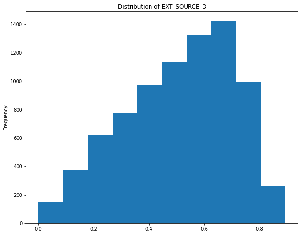

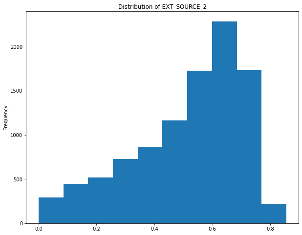

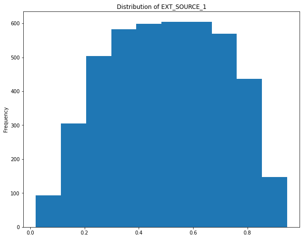

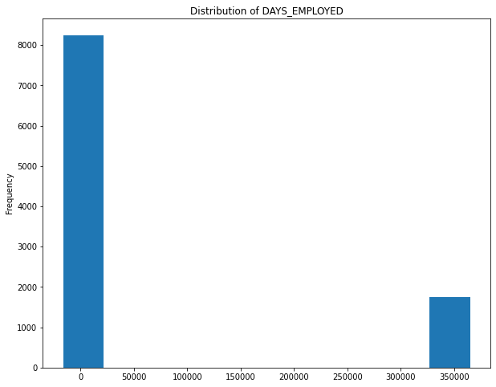

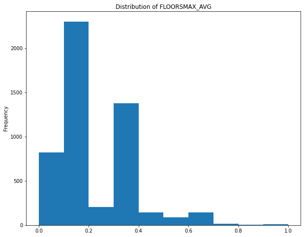

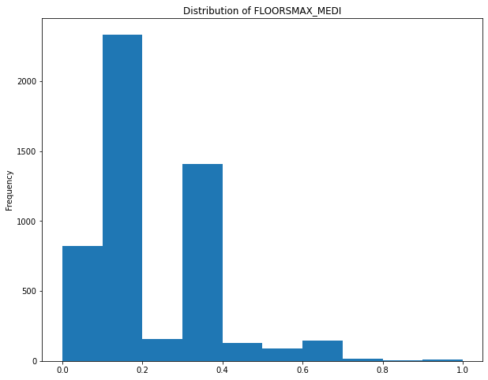

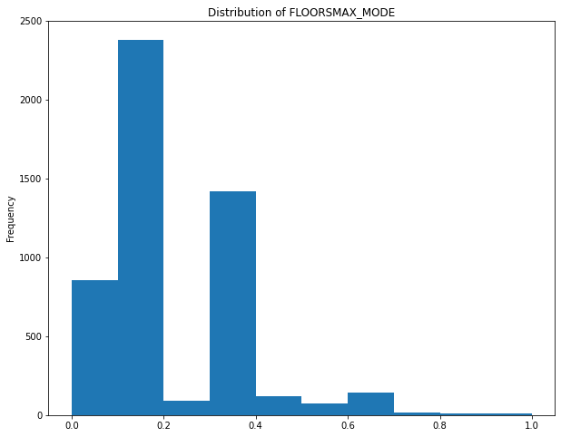

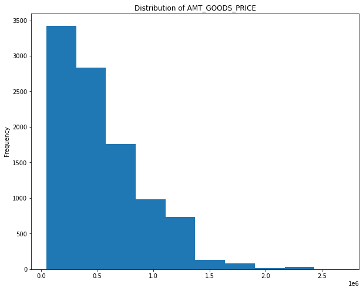

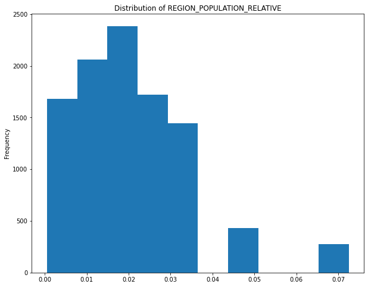

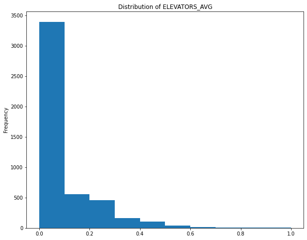

```python
#EXPLORE DISTRIBUTION FOR MOST NEGATIVELY CORRELATED FEATURES

for col in neg_cols:
    plt.figure(figsize=(10,8))
    plt.title(f"Distribution of {col}")
    train_data[col].dropna().plot.hist()
```

```python
pos_cols
```

```
['DAYS_REGISTRATION',
 'FLAG_DOCUMENT_3',
 'REG_CITY_NOT_LIVE_CITY',
 'FLAG_EMP_PHONE',
 'REG_CITY_NOT_WORK_CITY',
 'DAYS_ID_PUBLISH',
 'DAYS_LAST_PHONE_CHANGE',
 'REGION_RATING_CLIENT',
 'REGION_RATING_CLIENT_W_CITY',
 'DAYS_BIRTH',
 'TARGET']
```

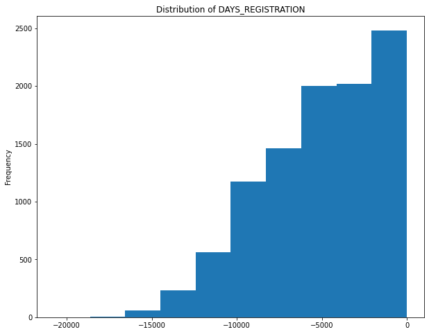

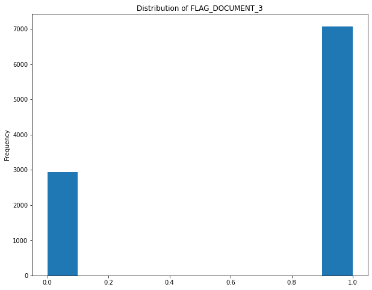

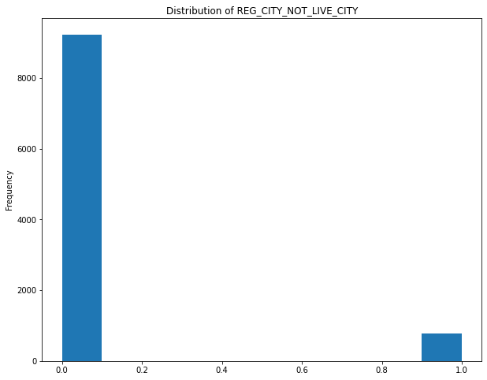

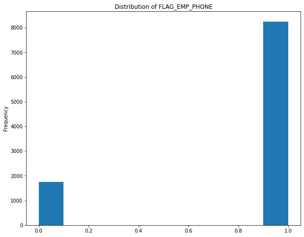

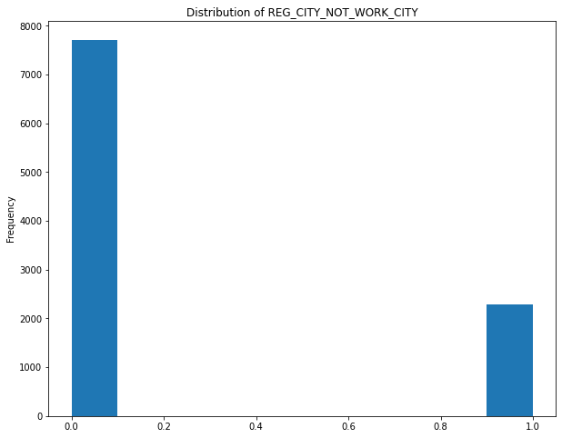

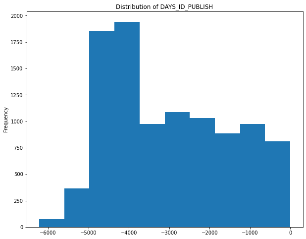

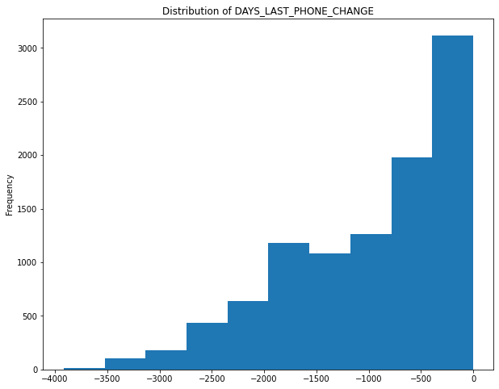

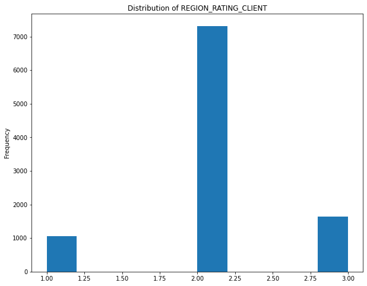

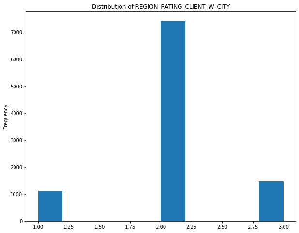

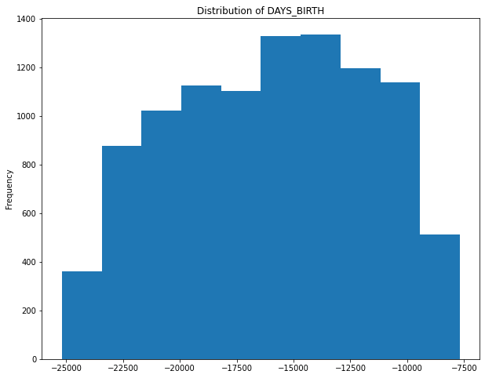

```python
# EXPLORE DISTRIBUTION FOR MOST NEGATIVELY CORRELATED FEATURES

for col in pos_cols[:-1]:
    plt.figure(figsize=(10,8))
    plt.title(f"Distribution of {col}")
    train_data[col].dropna().plot.hist()
```

# Train, Test, Split data from `application_train.csv`

Initial attempts were crashing kernels because the dataset was too large (over 300,000 records)

We are taking a random sample of 10,000 rows to allow our models to function. Future models may expand the size of the model training set to improve model performance.

```python
# Take random sample of overall training data
train_data = train_data.sample(10_000)
```

Create training, validation and testing data.

```python
X = train_data.drop('TARGET', axis=1)
y = train_data['TARGET']

# Split the provided training data into training and validationa and test
X_train, X_test, y_train, y_test = train_test_split(X, y, test_size=0.15, random_state=42)
X_train, X_valid, y_train, y_valid = train_test_split(X_train, y_train, test_size=0.2, random_state=42)
print(f"X train           shape: {X_train.shape}")
print(f"X validation      shape: {X_valid.shape}")
print(f"X test            shape: {X_test.shape}")


X_train.head()
```

```
X train           shape: (6800, 121)
X validation      shape: (1700, 121)
X test            shape: (1500, 121)
```

|  | SK_ID_CURR | NAME_CONTRACT_TYPE | CODE_GENDER | FLAG_OWN_CAR | FLAG_OWN_REALTY | CNT_CHILDREN | AMT_INCOME_TOTAL | AMT_CREDIT | AMT_ANNUITY | AMT_GOODS_PRICE | NAME_TYPE_SUITE | NAME_INCOME_TYPE | NAME_EDUCATION_TYPE | NAME_FAMILY_STATUS | NAME_HOUSING_TYPE | REGION_POPULATION_RELATIVE | DAYS_BIRTH | DAYS_EMPLOYED | DAYS_REGISTRATION | DAYS_ID_PUBLISH | OWN_CAR_AGE | FLAG_MOBIL | FLAG_EMP_PHONE | FLAG_WORK_PHONE | FLAG_CONT_MOBILE | FLAG_PHONE | FLAG_EMAIL | OCCUPATION_TYPE | CNT_FAM_MEMBERS | … |
| --- | --- | --- | --- | --- | --- | --- | --- | --- | --- | --- | --- | --- | --- | --- | --- | --- | --- | --- | --- | --- | --- | --- | --- | --- | --- | --- | --- | --- | --- | --- |
| 215244 | 349412 | Cash loans | F | Y | Y | 0 | 117000.0 | 592560.0 | 35806.5 | 450000.0 | Unaccompanied | Working | Secondary / secondary special | Married | House / apartment | 0.018029 | -13483 | -547 | -7537.0 | -4677 | 0.0 | 1 | 1 | 1 | 1 | 1 | 0 | Sales staff | 2.0 | … |
| 137066 | 258971 | Cash loans | M | N | Y | 0 | 112500.0 | 254700.0 | 16276.5 | 225000.0 | Unaccompanied | Working | Secondary / secondary special | Married | House / apartment | 0.018634 | -16345 | -4175 | -6490.0 | -4172 | NaN | 1 | 1 | 1 | 1 | 1 | 0 | Laborers | 2.0 | … |
| 126411 | 246600 | Revolving loans | M | Y | Y | 0 | 153000.0 | 180000.0 | 9000.0 | 180000.0 | Unaccompanied | Commercial associate | Higher education | Married | House / apartment | 0.022800 | -13813 | -254 | -4745.0 | -4250 | 7.0 | 1 | 1 | 0 | 1 | 0 | 0 | Drivers | 2.0 | … |
| 123541 | 243271 | Cash loans | F | N | N | 0 | 54000.0 | 261153.0 | 22414.5 | 225000.0 | Unaccompanied | Working | Higher education | Married | House / apartment | 0.019101 | -10330 | -483 | -3008.0 | -153 | NaN | 1 | 1 | 0 | 1 | 1 | 1 | Core staff | 2.0 | … |
| 165451 | 291801 | Cash loans | F | N | Y | 1 | 112500.0 | 1255680.0 | 41629.5 | 1125000.0 | Unaccompanied | Working | Secondary / secondary special | Married | House / apartment | 0.008019 | -18336 | -261 | -1533.0 | -1883 | NaN | 1 | 1 | 0 | 1 | 0 | 0 | Sales staff | 3.0 | … |

# Pipelines

## KNN Classification

[figure not shown]

```python
numeric_features = ['CNT_CHILDREN','AMT_INCOME_TOTAL', 'AMT_CREDIT', 'AMT_ANNUITY', 'AMT_GOODS_PRICE', 'DAYS_BIRTH', 'DAYS_EMPLOYED']
numeric_transformer = Pipeline(steps=[
    ('imputer', SimpleImputer(strategy='median')),
    ('scaler', StandardScaler())])

categorical_features = ['NAME_CONTRACT_TYPE', 'CODE_GENDER', 'FLAG_OWN_CAR', 'FLAG_OWN_REALTY','OCCUPATION_TYPE']
categorical_transformer = Pipeline(steps=[
    ('imputer', SimpleImputer(strategy='constant', fill_value='missing')),
    ('onehot', OneHotEncoder(handle_unknown='ignore'))])

preprocessor = ColumnTransformer(
    transformers=[
        ('num', numeric_transformer, numeric_features),
        ('cat', categorical_transformer, categorical_features)])

knn_model = Pipeline(steps=[('preprocessor', preprocessor),
                      ('classifier', KNeighborsClassifier())])


knn_model.fit(X_train, y_train)
print(knn_model.score(X_test, y_test))
```

```
0.9133333333333333
```

Create a log to compare the different models' perfomance.

Code adapted from `HW04-LinRegrBoston_Bike-Demand.ipynb`

```python
try:
    del expLog
except:
    pass

exp_name = "knn_baseline"
try:
    expLog
except NameError:
    expLog = DataFrame(columns=["exp_name",
                                   "Train Acc",
                                   "Valid Acc",
                                   "Test  Acc",
                                   "Train F1",
                                   "Valid F1",
                                   "Test  F1"
                                  ])

expLog.loc[len(expLog)] = [f"{exp_name}"] + list(np.round(
               [accuracy_score(y_train, knn_model.predict(X_train)),
                accuracy_score(y_valid, knn_model.predict(X_valid)),
                accuracy_score(y_test, knn_model.predict(X_test)),
                f1_score(y_train, knn_model.predict(X_train)),
                f1_score(y_valid, knn_model.predict(X_valid)),
                f1_score(y_test, knn_model.predict(X_test))],
    4))
expLog
```

|  | exp_name | Train Acc | Valid Acc | Test Acc | Train F1 | Valid F1 | Test F1 |
| --- | --- | --- | --- | --- | --- | --- | --- |
| 0 | knn_baseline | 0.9234 | 0.9282 | 0.9133 | 0.0876 | 0.0 | 0.058 |

## XG Boost Pipeline

```python
numeric_features = ['CNT_CHILDREN','AMT_INCOME_TOTAL', 'AMT_CREDIT', 'AMT_ANNUITY', 'AMT_GOODS_PRICE', 'DAYS_BIRTH', 'DAYS_EMPLOYED']
numeric_transformer = Pipeline(steps=[
    ('imputer', SimpleImputer(strategy='median')),
    ('scaler', StandardScaler())])

categorical_features = ['NAME_CONTRACT_TYPE', 'CODE_GENDER', 'FLAG_OWN_CAR', 'FLAG_OWN_REALTY','OCCUPATION_TYPE']
categorical_transformer = Pipeline(steps=[
    ('imputer', SimpleImputer(strategy='constant', fill_value='missing')),
    ('onehot', OneHotEncoder(handle_unknown='ignore'))])

preprocessor = ColumnTransformer(
    transformers=[
        ('num', numeric_transformer, numeric_features),
        ('cat', categorical_transformer, categorical_features)])

XGB_model = Pipeline(steps=[('preprocessor', preprocessor),
                      ('classifier', XGBClassifier())])


XGB_model.fit(X_train, y_train)
```

```
[02:18:51] WARNING: ../src/learner.cc:1115: Starting in XGBoost 1.3.0, the default evaluation metric used with the objective 'binary:logistic' was changed from 'error' to 'logloss'. Explicitly set eval_metric if you'd like to restore the old behavior.
```

```
Pipeline(steps=[('preprocessor',
                 ColumnTransformer(transformers=[('num',
                                                  Pipeline(steps=[('imputer',
                                                                   SimpleImputer(strategy='median')),
                                                                  ('scaler',
                                                                   StandardScaler())]),
                                                  ['CNT_CHILDREN',
                                                   'AMT_INCOME_TOTAL',
                                                   'AMT_CREDIT', 'AMT_ANNUITY',
                                                   'AMT_GOODS_PRICE',
                                                   'DAYS_BIRTH',
                                                   'DAYS_EMPLOYED']),
                                                 ('cat',
                                                  Pipeline(steps=[('imputer',
                                                                   SimpleImputer(fill_value='missing',
                                                                                 strategy...
                               gamma=0, gpu_id=-1, importance_type=None,
                               interaction_constraints='',
                               learning_rate=0.300000012, max_delta_step=0,
                               max_depth=6, min_child_weight=1, missing=nan,
                               monotone_constraints='()', n_estimators=100,
                               n_jobs=12, num_parallel_tree=1, predictor='auto',
                               random_state=0, reg_alpha=0, reg_lambda=1,
                               scale_pos_weight=1, subsample=1,
                               tree_method='exact', validate_parameters=1,
                               verbosity=None))])
```

```python
exp_name = "XGB_baseline"

expLog.loc[len(expLog)] = [f"{exp_name}"] + list(np.round(
               [accuracy_score(y_train, XGB_model.predict(X_train)),
                accuracy_score(y_valid, XGB_model.predict(X_valid)),
                accuracy_score(y_test, XGB_model.predict(X_test)),
                f1_score(y_train, XGB_model.predict(X_train)),
                f1_score(y_valid, XGB_model.predict(X_valid)),
                f1_score(y_test, XGB_model.predict(X_test))],
    4))

expLog
```

|  | exp_name | Train Acc | Valid Acc | Test Acc | Train F1 | Valid F1 | Test F1 |
| --- | --- | --- | --- | --- | --- | --- | --- |
| 0 | knn_baseline | 0.9234 | 0.9282 | 0.9133 | 0.0876 | 0.0000 | 0.058 |
| 1 | XGB_baseline | 0.9638 | 0.9300 | 0.9127 | 0.7007 | 0.0165 | 0.015 |

## Logistic Regression Pipeline

```python
numeric_features = ['CNT_CHILDREN','AMT_INCOME_TOTAL', 'AMT_CREDIT', 'AMT_ANNUITY', 'AMT_GOODS_PRICE', 'DAYS_BIRTH', 'DAYS_EMPLOYED']
numeric_transformer = Pipeline(steps=[
    ('imputer', SimpleImputer(strategy='median')),
    ('scaler', StandardScaler())])

categorical_features = ['NAME_CONTRACT_TYPE', 'CODE_GENDER', 'FLAG_OWN_CAR', 'FLAG_OWN_REALTY','OCCUPATION_TYPE']
categorical_transformer = Pipeline(steps=[
    ('imputer', SimpleImputer(strategy='constant', fill_value='missing')),
    ('onehot', OneHotEncoder(handle_unknown='ignore'))])

preprocessor = ColumnTransformer(
    transformers=[
        ('num', numeric_transformer, numeric_features),
        ('cat', categorical_transformer, categorical_features)])

logreg_model = Pipeline(steps=[('preprocessor', preprocessor),
                      ('classifier', LogisticRegression(max_iter=10000))])


logreg_model.fit(X_train, y_train)
```

```
Pipeline(steps=[('preprocessor',
                 ColumnTransformer(transformers=[('num',
                                                  Pipeline(steps=[('imputer',
                                                                   SimpleImputer(strategy='median')),
                                                                  ('scaler',
                                                                   StandardScaler())]),
                                                  ['CNT_CHILDREN',
                                                   'AMT_INCOME_TOTAL',
                                                   'AMT_CREDIT', 'AMT_ANNUITY',
                                                   'AMT_GOODS_PRICE',
                                                   'DAYS_BIRTH',
                                                   'DAYS_EMPLOYED']),
                                                 ('cat',
                                                  Pipeline(steps=[('imputer',
                                                                   SimpleImputer(fill_value='missing',
                                                                                 strategy='constant')),
                                                                  ('onehot',
                                                                   OneHotEncoder(handle_unknown='ignore'))]),
                                                  ['NAME_CONTRACT_TYPE',
                                                   'CODE_GENDER',
                                                   'FLAG_OWN_CAR',
                                                   'FLAG_OWN_REALTY',
                                                   'OCCUPATION_TYPE'])])),
                ('classifier', LogisticRegression(max_iter=10000))])
```

```python
exp_name = "logreg_baseline"

expLog.loc[len(expLog)] = [f"{exp_name}"] + list(np.round(
               [accuracy_score(y_train, logreg_model.predict(X_train)),
                accuracy_score(y_valid, logreg_model.predict(X_valid)),
                accuracy_score(y_test, logreg_model.predict(X_test)),
                f1_score(y_train, logreg_model.predict(X_train)),
                f1_score(y_valid, logreg_model.predict(X_valid)),
                f1_score(y_test, logreg_model.predict(X_test))],
    4))
expLog
```

|  | exp_name | Train Acc | Valid Acc | Test Acc | Train F1 | Valid F1 | Test F1 |
| --- | --- | --- | --- | --- | --- | --- | --- |
| 0 | knn_baseline | 0.9234 | 0.9282 | 0.9133 | 0.0876 | 0.0000 | 0.058 |
| 1 | XGB_baseline | 0.9638 | 0.9300 | 0.9127 | 0.7007 | 0.0165 | 0.015 |
| 2 | logreg_baseline | 0.9216 | 0.9329 | 0.9160 | 0.0000 | 0.0000 | 0.000 |

# Results

The baseline models all performed relatively well in predicting an outcome of a customer's default risk in both the validation and test sets in terms of accuracy. However the F1 scores are extremely low for all models. Since the F1 score is a combination of precision and recall, this implies one of those two metrics may be zero.

Precision is defined as

$$ \frac{\text{True Positives}}{\text{True Positives} + \text{False Positives}} $$

Recall is defined as

$$ \frac{\text{True Positives}}{\text{True Positives} + \text{False Negatives}} $$

The target is imbalanced, since 92.2% of the customers did not default. It is possible there are 0 True Positives in the validation and test set.

```python
train_data['TARGET'].value_counts(normalize=True)
```

```
0    0.9227
1    0.0773
Name: TARGET, dtype: float64
```

```python
print (f'The target class is 1 in the validation data: {round(y_valid.sum() / len(y_valid), 4)}')

print (f'The target class is 1 in the test data: {round(y_test.sum() / len(y_test), 4)}')
```

```
The target class is 1 in the validation data: 0.0671
The target class is 1 in the test data: 0.084
```

# Conclusions

The goal of this project is to use the data as provided by Kaggle and predict whether or not a client will repay a loan. The target column contains a 1 if the client does not pay their loan and is a credit risk.

This phase of the project dealt mainly with creating baseline pipelines and models. These model metrics will help guide our future efforts as we perform feature engineering, add and remove features, and use GridSearch to tune model hyperparameters.

Our key steps:

- Download and load the data from Kaggle.
- Perform exploratory data analysis (EDA).
- Define several baseline classification models using KNN, XG Boost and Logistic Regression.
- Create pipelines to standardize any numerical feature and one hot encode categorial features.
- Calculate several metrics to evaluate each model and pipeline.

Results are slightly misleading because a high accuracy score does not necessarily imply a quality model. If the model predicts 0 for every record in the test set, it would be correct around 92% of the time.

Future steps will include further investigation into the various features in the data sets. Checking for multicollinearity may identify issues with feature selection as well. We intend to build a neural network model and compare it's performance to the baseline models above.

# Credit assignment plan

[figure not shown]